# Visit With Us Procject

# Exploratory Data Analysis of Current Product Sales and Customer Trends

Below, customer trends for current product sales are visualized and explored to gain insight into current sales operations. Later on in this notebook, these same visualizations will be compared against predicted wellness tourism customers to attempt a differentiation

```python
#create dataset of records where the customer purchased a travel package for further analysis
dat_analysis = df[df['ProdTaken']==1]
```

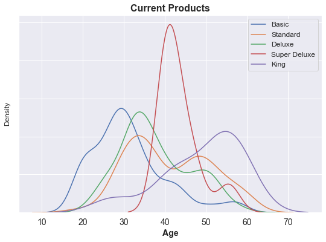

```python
# which packge choosen by most age of people
fig = plt.figure(figsize=[9,6]);
sns.distplot(dat_analysis.loc[dat_analysis['ProductPitched'] == 'Basic','Age'], kde=True, hist=False, label='Basic');
sns.distplot(dat_analysis.loc[dat_analysis['ProductPitched'] == 'Standard','Age'], kde=True, hist=False, label='Standard');
sns.distplot(dat_analysis.loc[dat_analysis['ProductPitched'] == 'Deluxe','Age'], kde=True, hist=False, label='Deluxe');
sns.distplot(dat_analysis.loc[dat_analysis['ProductPitched'] == 'Super Deluxe','Age'], kde=True, hist=False, label='Super Deluxe');
sns.distplot(dat_analysis.loc[dat_analysis['ProductPitched'] == 'King','Age'], kde=True, hist=False, label='King');
plt.yticks(np.arange(0,0.12,0.02),labels=['','','','','','']);
plt.xticks(fontsize=14)
plt.xlabel('Age', fontsize=14, fontweight='bold');
plt.legend(fontsize=12);
plt.title('Current Products', fontsize=16, fontweight='bold');
```

Basic package: popular with customers in their 20s, 30s, and 40s Standard and Deluxe packages: skewed towards customers in their 30s and 40s Super Deluxe package: popular with customers in their 40s and 50s King package: popular with customers in their 40s and 50s

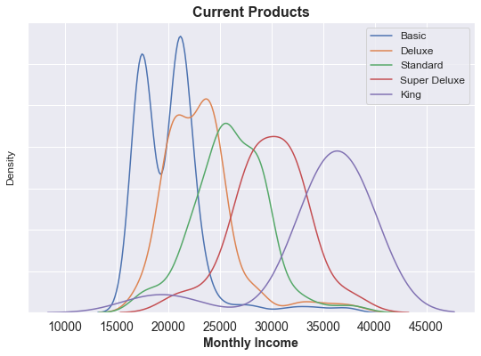

```python
# Monthly Income for people who go to trip
fig = plt.figure(figsize=[9,6]);
sns.distplot(dat_analysis.loc[dat_analysis['ProductPitched'] == 'Basic','MonthlyIncome'], kde=True, hist=False, label='Basic');
sns.distplot(dat_analysis.loc[dat_analysis['ProductPitched'] == 'Deluxe','MonthlyIncome'], kde=True, hist=False, label='Deluxe');
sns.distplot(dat_analysis.loc[dat_analysis['ProductPitched'] == 'Standard','MonthlyIncome'], kde=True, hist=False, label='Standard');
sns.distplot(dat_analysis.loc[dat_analysis['ProductPitched'] == 'Super Deluxe','MonthlyIncome'], kde=True, hist=False, label='Super Deluxe');
sns.distplot(dat_analysis.loc[dat_analysis['ProductPitched'] == 'King','MonthlyIncome'], kde=True, hist=False, label='King');
plt.yticks(np.arange(0,0.0002,0.000025),labels=['','','','','','','','']);
plt.xticks(fontsize=14);
plt.xlabel('Monthly Income', fontsize=14, fontweight='bold');
plt.legend(fontsize=12);
plt.title('Current Products', fontsize=16, fontweight='bold');
```

Those customers has most purchased a Basic package whose Monthly income is between 15000 to 25000. And those people pucharse the king pakage whose monthly income between 35000 to 45000 which is quite high range.

Basic Package: Popular with customers with income range between 15k and 25k Deluxe Package: Popular with customers with income range between 20k and 30k Standard Package: Popular with customers with income range between 20k and 35k Super Deluxe Package: Popular with income range between 25k and 35k King: Popular with customers with income range between 30k and 45k.

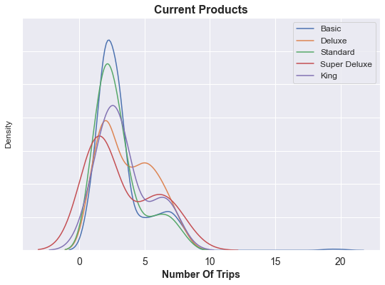

```python
# Plot Number Of Trips
fig = plt.figure(figsize=[9,6]);
sns.distplot(dat_analysis.loc[dat_analysis['ProductPitched'] == 'Basic','NumberOfTrips'], kde=True, hist=False, label='Basic');
sns.distplot(dat_analysis.loc[dat_analysis['ProductPitched'] == 'Deluxe','NumberOfTrips'], kde=True, hist=False, label='Deluxe');
sns.distplot(dat_analysis.loc[dat_analysis['ProductPitched'] == 'Standard','NumberOfTrips'], kde=True, hist=False, label='Standard');
sns.distplot(dat_analysis.loc[dat_analysis['ProductPitched'] == 'Super Deluxe','NumberOfTrips'], kde=True, hist=False, label='Super Deluxe');
sns.distplot(dat_analysis.loc[dat_analysis['ProductPitched'] == 'King','NumberOfTrips'], kde=True, hist=False, label='King');
plt.yticks(np.arange(0,0.4,0.05),labels=['','','','','','','','']);
plt.xticks(fontsize=14);
plt.xlabel('Number Of Trips', fontsize=14, fontweight='bold');
plt.legend(fontsize=12);
plt.title('Current Products', fontsize=16, fontweight='bold');
```

Average number of trips are between 0 to 5 in a year and those trips are basic package trips.

Number of trips appears to be consistent across all product offerings

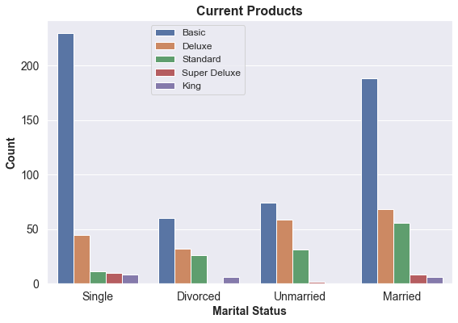

```python
# Marital Status
fig = plt.figure(figsize=[9,6]);
sns.countplot(data=dat_analysis, x='MaritalStatus', hue='ProductPitched', order=['Single','Divorced','Unmarried','Married'],hue_order=['Basic','Deluxe','Standard','Super Deluxe','King'])
plt.xticks(fontsize=14);
plt.xlabel('Marital Status', fontsize=14, fontweight='bold');
plt.yticks(fontsize=14);
plt.ylabel('Count', fontsize=14, fontweight='bold');
plt.legend(fontsize=12, bbox_to_anchor=(0.5,1));
plt.title('Current Products', fontsize=16, fontweight='bold');
```

Marital status of customer who has purchased a basic package most are Single and Married

Single and Married substantially more likely to purchase a basic travel package, though Married have higher likelihood than single a deluxe or standard package. Divorced and Unmarried far more likely to purchase Standard and Deluxe packages. Super Deluxe does not appear to be popular among Divorced and King does not appear to be popular among Unmarrier, though this is likely due to a limited number of samples.

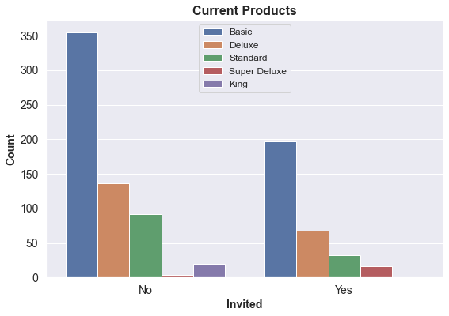

```python
# Invited to wchich package
fig = plt.figure(figsize=[9,6]);
sns.countplot(data=dat_analysis, x='Invited', hue='ProductPitched', hue_order=['Basic','Deluxe','Standard','Super Deluxe','King']);
plt.xticks([0,1],labels=['No','Yes'],fontsize=14);
plt.xlabel('Invited', fontsize=14, fontweight='bold');
plt.yticks(fontsize=14);
plt.ylabel('Count', fontsize=14, fontweight='bold');
plt.legend(fontsize=12);
plt.title('Current Products', fontsize=16, fontweight='bold');
```

Invited customers do not appear to be any more likely to purchase a travel package.

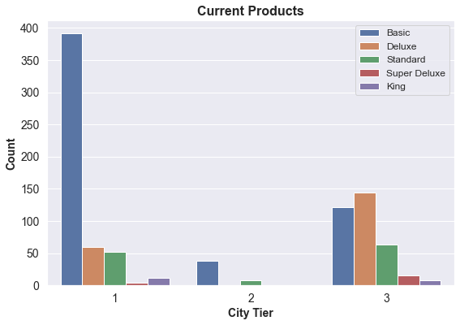

```python
# City Tier
fig = plt.figure(figsize=[9,6]);
sns.countplot(data=dat_analysis, x='CityTier', hue='ProductPitched', hue_order=['Basic','Deluxe','Standard','Super Deluxe','King']);
plt.xticks(fontsize=14);
plt.xlabel('City Tier', fontsize=14, fontweight='bold');
plt.yticks(fontsize=14);
plt.ylabel('Count', fontsize=14, fontweight='bold');
plt.legend(fontsize=12);
plt.title('Current Products', fontsize=16, fontweight='bold');
```

Customers from city tier 1 appear highly likely to purchase a basic travel package. Customers from City tier 2 do not appear likely to purchase any travel package. And customers from city tier 3 have higher likelihood than other tiers of purchases greater travel packages.

Observations

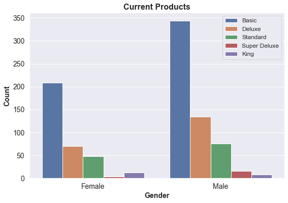

```python
# Gender which choose package
fig = plt.figure(figsize=[9,6]);
sns.countplot(data=dat_analysis, x='Gender', hue='ProductPitched', hue_order=['Basic','Deluxe','Standard','Super Deluxe','King']);
plt.xticks(fontsize=14);
plt.xlabel('Gender', fontsize=14, fontweight='bold');
plt.yticks(fontsize=14);
plt.ylabel('Count', fontsize=14, fontweight='bold');
plt.legend(fontsize=12);
plt.title('Current Products', fontsize=16, fontweight='bold');
```

Males are more likely than females to purchase a travel package though when males (or females) purchase they are likely to be purchasing for themselves and a partner or family.

Observations

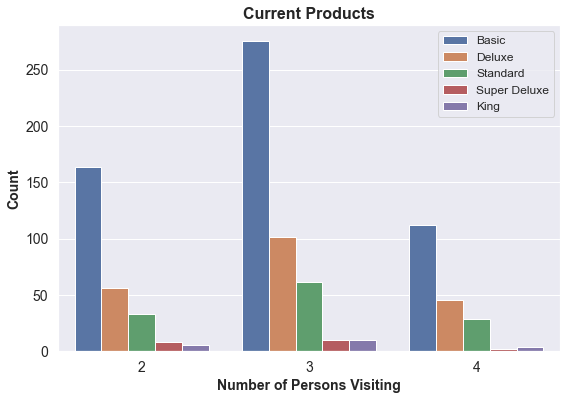

```python
# Number Of PersonVisiting
fig = plt.figure(figsize=[9,6]);
sns.countplot(data=dat_analysis, x='NumberOfPersonVisiting', hue='ProductPitched', hue_order=['Basic','Deluxe','Standard','Super Deluxe','King']);
plt.xticks(fontsize=14);
plt.xlabel('Number of Persons Visiting', fontsize=14, fontweight='bold');
plt.yticks(fontsize=14);
plt.ylabel('Count', fontsize=14, fontweight='bold');
plt.legend(fontsize=12);
plt.title('Current Products', fontsize=16, fontweight='bold');
```

Of those that purchased a package, none came to pitch alone. Customers were most likely to purchase if they came with 3 or less people. The dip in sales with customers visiting with 4 or more vistors is likely due to lower discretionary income from having a lot of children.

Observations

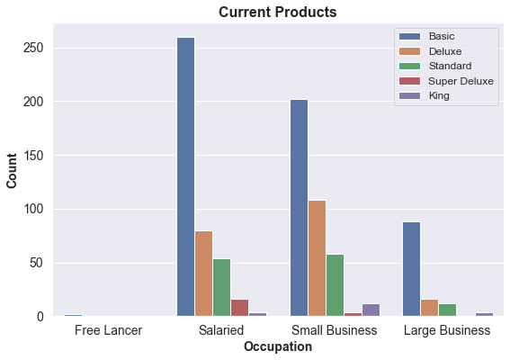

```python
fig = plt.figure(figsize=[9,6]);
sns.countplot(data=dat_analysis, x='Occupation', hue='ProductPitched', order=['Free Lancer','Salaried','Small Business','Large Business'],hue_order=['Basic','Deluxe','Standard','Super Deluxe','King']);
plt.xticks(fontsize=14);
plt.xlabel('Occupation', fontsize=14, fontweight='bold');
plt.yticks(fontsize=14);
plt.ylabel('Count', fontsize=14, fontweight='bold');
plt.legend(fontsize=12);
plt.title('Current Products', fontsize=16, fontweight='bold');
```

Free lancers appear to be unlikely to purchase a travel package, likely due to low income, this may also be due to a limited amount of representative samples for that population. Small business employees have a higher likelihood than other employees of purchasing higher end travel packages.